# Football-Events

A game of football has much more scope for analysis than the commonly used statistics like number of goals, number of cards etc. To analyze the events and their impact and also the betting stats, lets look at a secondary dataset.

|  | id_odsp | id_event | sort_order | time | text | event_type | event_type2 | side | event_team | opponent | player | player2 | player_in | player_out | shot_place | shot_outcome | is_goal | location | bodypart | assist_method | situation | fast_break |
| --- | --- | --- | --- | --- | --- | --- | --- | --- | --- | --- | --- | --- | --- | --- | --- | --- | --- | --- | --- | --- | --- | --- |
| 0 | UFot0hit/ | UFot0hit1 | 1 | 2 | Attempt missed. Mladen Petric (Hamburg) left f... | 1 | 12.0 | 2 | Hamburg SV | Borussia Dortmund | mladen petric | gokhan tore | NaN | NaN | 6.0 | 2.0 | 0 | 9.0 | 2.0 | 1 | 1.0 | 0 |
| 1 | UFot0hit/ | UFot0hit2 | 2 | 4 | Corner, Borussia Dortmund. Conceded by Dennis... | 2 | NaN | 1 | Borussia Dortmund | Hamburg SV | dennis diekmeier | dennis diekmeier | NaN | NaN | NaN | NaN | 0 | NaN | NaN | 0 | NaN | 0 |

```
(941009, 22)
```

So we have almost a million events in the dataset

We have one more file in the dataset. Lets look at it as well

|  | id_odsp | link_odsp | adv_stats | date | league | season | country | ht | at | fthg | ftag | odd_h | odd_d | odd_a | odd_over | odd_under | odd_bts | odd_bts_n |
| --- | --- | --- | --- | --- | --- | --- | --- | --- | --- | --- | --- | --- | --- | --- | --- | --- | --- | --- |
| 0 | UFot0hit/ | /soccer/germany/bundesliga-2011-2012/dortmund-... | True | 2011-08-05 | D1 | 2012 | germany | Borussia Dortmund | Hamburg SV | 3 | 1 | 1.56 | 4.41 | 7.42 | NaN | NaN | NaN | NaN |
| 1 | Aw5DflLH/ | /soccer/germany/bundesliga-2011-2012/augsburg-... | True | 2011-08-06 | D1 | 2012 | germany | FC Augsburg | SC Freiburg | 2 | 2 | 2.36 | 3.60 | 3.40 | NaN | NaN | NaN | NaN |
| 2 | bkjpaC6n/ | /soccer/germany/bundesliga-2011-2012/werder-br... | True | 2011-08-06 | D1 | 2012 | germany | Werder Bremen | Kaiserslautern | 2 | 0 | 1.83 | 4.20 | 4.80 | NaN | NaN | NaN | NaN |
| 3 | CzPV312a/ | /soccer/france/ligue-1-2011-2012/paris-sg-lori... | True | 2011-08-06 | F1 | 2012 | france | Paris Saint-Germain | Lorient | 0 | 1 | 1.55 | 4.50 | 9.40 | NaN | NaN | NaN | NaN |
| 4 | GUOdmtII/ | /soccer/france/ligue-1-2011-2012/caen-valencie... | True | 2011-08-06 | F1 | 2012 | france | Caen | Valenciennes | 1 | 0 | 2.50 | 3.40 | 3.45 | NaN | NaN | NaN | NaN |

|  | id_odsp | date | league | season | country | odd_h | odd_d | odd_a | fthg | ftag | prob_h | prob_a | prob_d | pred_h_win | pred_a_win | pred_draw | h_win | a_win | draw |
| --- | --- | --- | --- | --- | --- | --- | --- | --- | --- | --- | --- | --- | --- | --- | --- | --- | --- | --- | --- |
| 0 | UFot0hit/ | 2011-08-05 | D1 | 2012 | germany | 1.56 | 4.41 | 7.42 | 3 | 1 | 2.56 | 8.42 | 5.41 | 1 | 0 | 1 | 1 | 0 | 0 |
| 1 | Aw5DflLH/ | 2011-08-06 | D1 | 2012 | germany | 2.36 | 3.60 | 3.40 | 2 | 2 | 3.36 | 4.40 | 4.60 | 1 | 0 | 0 | 0 | 0 | 1 |
| 2 | bkjpaC6n/ | 2011-08-06 | D1 | 2012 | germany | 1.83 | 4.20 | 4.80 | 2 | 0 | 2.83 | 5.80 | 5.20 | 1 | 0 | 0 | 1 | 0 | 0 |
| 3 | CzPV312a/ | 2011-08-06 | F1 | 2012 | france | 1.55 | 4.50 | 9.40 | 0 | 1 | 2.55 | 10.40 | 5.50 | 1 | 0 | 1 | 0 | 1 | 0 |
| 4 | GUOdmtII/ | 2011-08-06 | F1 | 2012 | france | 2.50 | 3.40 | 3.45 | 1 | 0 | 3.50 | 4.45 | 4.40 | 1 | 0 | 0 | 1 | 0 | 0 |

This dataset uses cryptic names like D1, F1 etc for the leagues. Lets replace the values to have the same set of names that we used in the original match result dataset

| league | country | id_odsp | date | league | season | country | odd_h | odd_d | odd_a | fthg | ftag | prob_h | prob_a | prob_d | pred_h_win | pred_a_win | pred_draw | h_win | a_win | draw |
| --- | --- | --- | --- | --- | --- | --- | --- | --- | --- | --- | --- | --- | --- | --- | --- | --- | --- | --- | --- | --- |
| D1 | germany | 1690 | 526 | 1 | 6 | 1 | 358 | 240 | 500 | 10 | 8 | 358 | 500 | 240 | 2 | 2 | 2 | 2 | 2 | 2 |
| E0 | england | 2120 | 553 | 1 | 6 | 1 | 358 | 227 | 498 | 9 | 7 | 358 | 498 | 227 | 2 | 2 | 2 | 2 | 2 | 2 |
| F1 | france | 2107 | 594 | 1 | 6 | 1 | 347 | 224 | 507 | 7 | 9 | 347 | 507 | 224 | 2 | 2 | 2 | 2 | 2 | 2 |
| I1 | italy | 2106 | 541 | 1 | 6 | 1 | 361 | 268 | 516 | 8 | 8 | 361 | 516 | 268 | 2 | 2 | 2 | 2 | 2 | 2 |
| SP1 | spain | 2089 | 681 | 1 | 6 | 1 | 390 | 304 | 572 | 11 | 9 | 390 | 572 | 304 | 2 | 2 | 2 | 2 | 2 | 2 |

So E0 means EPL, SP1 means La Liga, I1 means Serie A, F1 means Ligue1 and D1 means Bundesliga

| league | country | id_odsp | date | league | season | country | odd_h | odd_d | odd_a | fthg | ftag | prob_h | prob_a | prob_d | pred_h_win | pred_a_win | pred_draw | h_win | a_win | draw |
| --- | --- | --- | --- | --- | --- | --- | --- | --- | --- | --- | --- | --- | --- | --- | --- | --- | --- | --- | --- | --- |
| Bundesliga | germany | 1690 | 526 | 1 | 6 | 1 | 358 | 240 | 500 | 10 | 8 | 358 | 500 | 240 | 2 | 2 | 2 | 2 | 2 | 2 |
| EPL | england | 2120 | 553 | 1 | 6 | 1 | 358 | 227 | 498 | 9 | 7 | 358 | 498 | 227 | 2 | 2 | 2 | 2 | 2 | 2 |
| LaLiga | spain | 2089 | 681 | 1 | 6 | 1 | 390 | 304 | 572 | 11 | 9 | 390 | 572 | 304 | 2 | 2 | 2 | 2 | 2 | 2 |
| Ligue1 | france | 2107 | 594 | 1 | 6 | 1 | 347 | 224 | 507 | 7 | 9 | 347 | 507 | 224 | 2 | 2 | 2 | 2 | 2 | 2 |
| SerieA | italy | 2106 | 541 | 1 | 6 | 1 | 361 | 268 | 516 | 8 | 8 | 361 | 516 | 268 | 2 | 2 | 2 | 2 | 2 | 2 |

Lets merge the two dataframes together

|  | id_odsp | id_event | sort_order | time | text | event_type | event_type2 | side | event_team | opponent | player | player2 | player_in | player_out | shot_place | shot_outcome | is_goal | location | bodypart | assist_method | situation | fast_break | date | league | season | country | odd_h | odd_d | odd_a | … |
| --- | --- | --- | --- | --- | --- | --- | --- | --- | --- | --- | --- | --- | --- | --- | --- | --- | --- | --- | --- | --- | --- | --- | --- | --- | --- | --- | --- | --- | --- | --- |
| 0 | UFot0hit/ | UFot0hit1 | 1 | 2 | Attempt missed. Mladen Petric (Hamburg) left f... | 1 | 12.0 | 2 | Hamburg SV | Borussia Dortmund | mladen petric | gokhan tore | NaN | NaN | 6.0 | 2.0 | 0 | 9.0 | 2.0 | 1 | 1.0 | 0 | 2011-08-05 | Bundesliga | 2012 | germany | 1.56 | 4.41 | 7.42 | … |
| 1 | UFot0hit/ | UFot0hit2 | 2 | 4 | Corner, Borussia Dortmund. Conceded by Dennis... | 2 | NaN | 1 | Borussia Dortmund | Hamburg SV | dennis diekmeier | dennis diekmeier | NaN | NaN | NaN | NaN | 0 | NaN | NaN | 0 | NaN | 0 | 2011-08-05 | Bundesliga | 2012 | germany | 1.56 | 4.41 | 7.42 | … |

The data has a lot of columns with cryptic numeric values. Lets use the dictionary file to replace the cryptic values with meaningful data instead

Lets look at the dataset once again now

|  | id_odsp | id_event | sort_order | time | text | event_type | event_type2 | side | event_team | opponent | player | player2 | player_in | player_out | shot_place | shot_outcome | is_goal | location | bodypart | assist_method | situation | fast_break | date | league | season | country | odd_h | odd_d | odd_a | … |
| --- | --- | --- | --- | --- | --- | --- | --- | --- | --- | --- | --- | --- | --- | --- | --- | --- | --- | --- | --- | --- | --- | --- | --- | --- | --- | --- | --- | --- | --- | --- |
| 0 | UFot0hit/ | UFot0hit1 | 1 | 2 | Attempt missed. Mladen Petric (Hamburg) left f... | Attempt | Key Pass | Away | Hamburg SV | Borussia Dortmund | mladen petric | gokhan tore | NaN | NaN | High and wide | Off target | 0 | Left side of the box | left foot | Pass | Open play | 0 | 2011-08-05 | Bundesliga | 2011-2012 | germany | 1.56 | 4.41 | 7.42 | … |
| 1 | UFot0hit/ | UFot0hit2 | 2 | 4 | Corner, Borussia Dortmund. Conceded by Dennis... | Corner | NaN | Home | Borussia Dortmund | Hamburg SV | dennis diekmeier | dennis diekmeier | NaN | NaN | NaN | NaN | 0 | NaN | NaN | None | NaN | 0 | 2011-08-05 | Bundesliga | 2011-2012 | germany | 1.56 | 4.41 | 7.42 | … |
| 2 | UFot0hit/ | UFot0hit3 | 3 | 4 | Corner, Borussia Dortmund. Conceded by Heiko ... | Corner | NaN | Home | Borussia Dortmund | Hamburg SV | heiko westermann | heiko westermann | NaN | NaN | NaN | NaN | 0 | NaN | NaN | None | NaN | 0 | 2011-08-05 | Bundesliga | 2011-2012 | germany | 1.56 | 4.41 | 7.42 | … |
| 3 | UFot0hit/ | UFot0hit4 | 4 | 7 | Foul by Sven Bender (Borussia Dortmund). | Foul | NaN | Home | Borussia Dortmund | Hamburg SV | sven bender | NaN | NaN | NaN | NaN | NaN | 0 | NaN | NaN | None | NaN | 0 | 2011-08-05 | Bundesliga | 2011-2012 | germany | 1.56 | 4.41 | 7.42 | … |
| 4 | UFot0hit/ | UFot0hit5 | 5 | 7 | Gokhan Tore (Hamburg) wins a free kick in the ... | Free kick won | NaN | Away | Hamburg SV | Borussia Dortmund | gokhan tore | NaN | NaN | NaN | NaN | NaN | 0 | Defensive half | NaN | None | NaN | 0 | 2011-08-05 | Bundesliga | 2011-2012 | germany | 1.56 | 4.41 | 7.42 | … |

Now the event dataset is ready for analysis

Lets visualize the number of occurences for each type of event

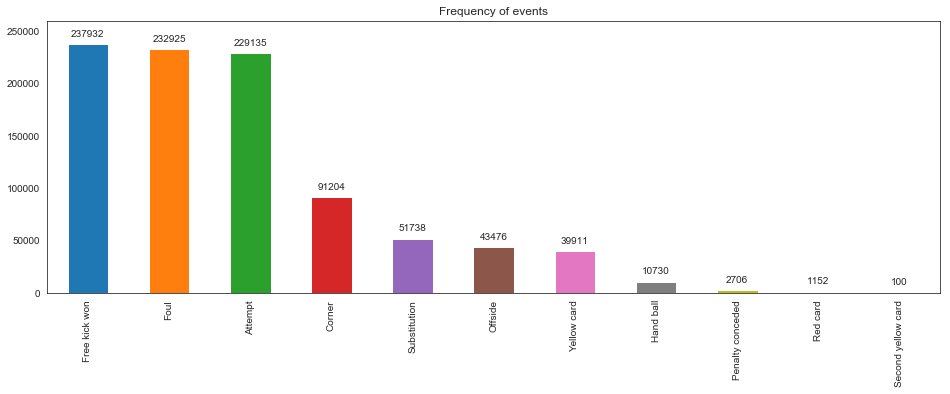

Overall, the most frequent events are :

1. Free kick won
2. Foul
3. Attempt

Lets look at a league wise view of the number of events

a) **English Premier League**

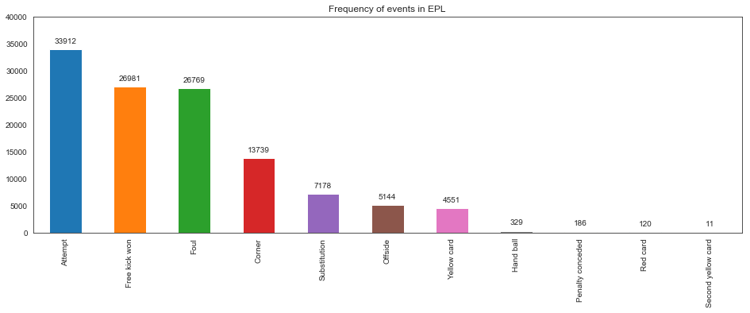

Foul moves from no 2 to no 3 position. This is consistent with our observation from the previous dataset that EPL has lesser number of fouls.

Attempt moves from no 3 to no 1 position. This is consistent with our observation from the other dataset that EPL has higher number of shots at goal as compared to other leagues

b) **La Liga**

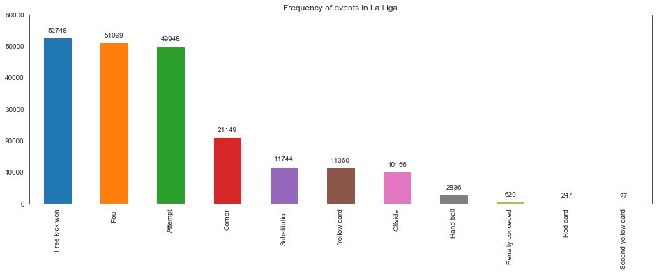

c) **Serie A**

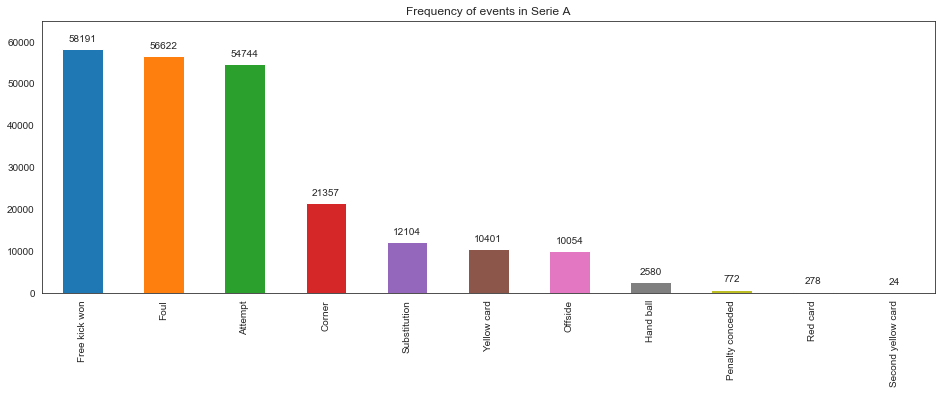

d) **Bundesliga**

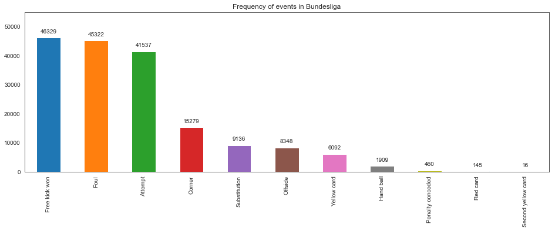

e) **Ligue One**

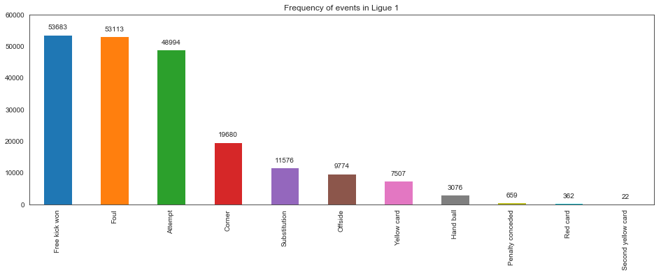

So the top 3 events in every league are Free kick won, Fouls and Attempts. EPL witnesses almost half the number of Fouls as LaLiga even though both the leagues involve equal number of games per season

## Where to shoot if you want to score a goal ?

Lets look at the shots that resulted in goals

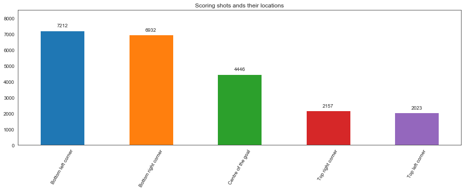

The data suggests that its more effective to shoot at the bottom than to shoot at the top or centre

Lets have a look at the missed attempts as well

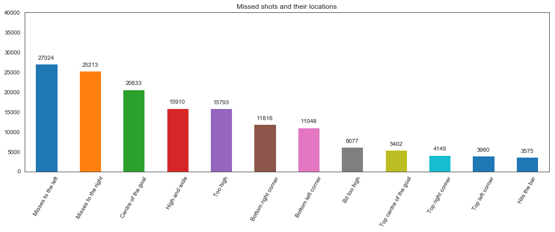

The number of saves in bottom left/right corner is quite low as opposed to centre of the box

There are fewer saves at top left/right corner but the chances of missing are high (might hit the bar or may be too high)

So, we can conclude that bottom right or left corners are the best locations to aim at while trying to score a goal

## Which teams and players are the most prolific scorers ?

Lets have a look at the most heavily scoring teams first

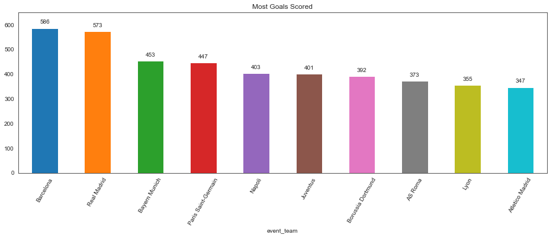

Barcelona and Real Madrid are at the top. This is also in line with our observation that La Liga witnesses high number of goals.

Interestingly none of the EPL teams make it to this list

Lets have a look at most prolific individual scorers now

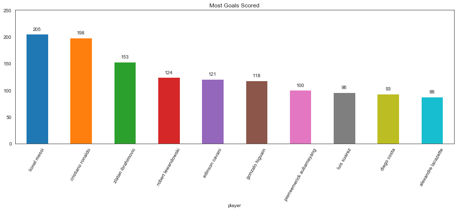

No surprises there in the top two names !!!

Zlatan Ibrahimovic is the only player to make it to this list after playing in three different leagues during this period

The players in the above chart might have high number of misses as well. Lets look at the players with maximum number of missed attempts

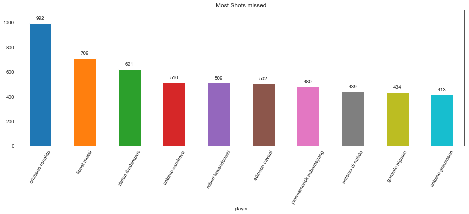

The top 3 are still Cristiano Ronaldo, Lionel Messi and Zlatan Ibrahimovic

Let's have a look at total number of Attempts as well

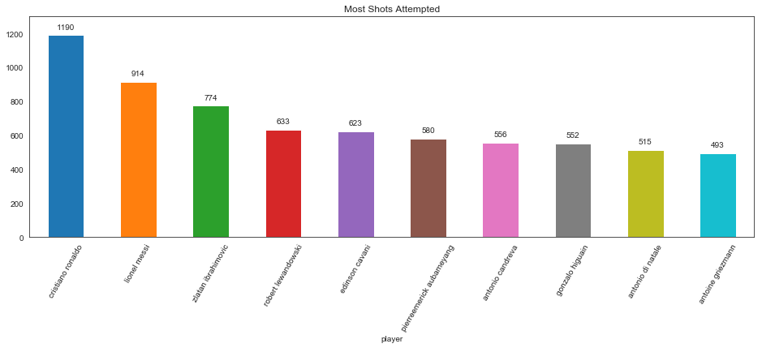

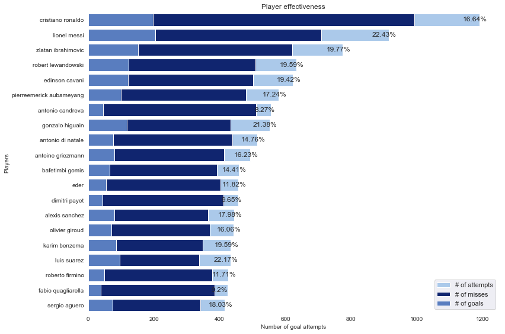

Clearly Christiano Ronaldo and Lionel Messi are considered among greatest off all times because they have been consistently creating chances.

## Which teams and players commit the maximum number of fouls ?

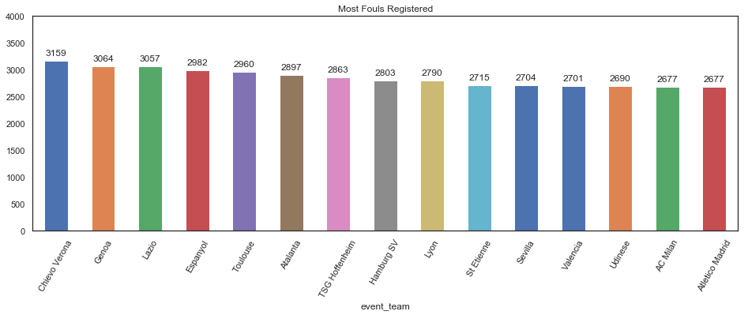

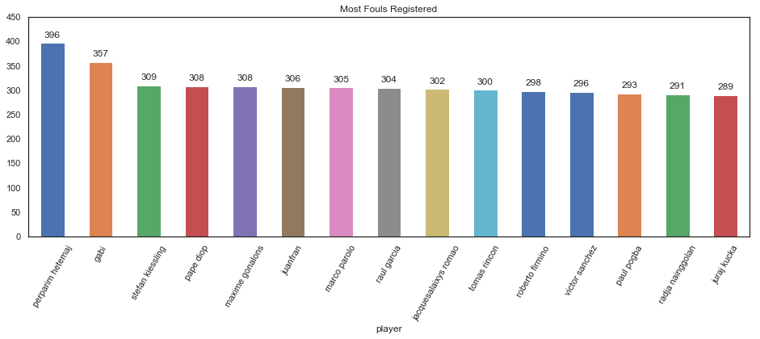

Surprising to not see Sergio Ramos among top 15

Lets look the card data as well, there should be some correlation between the two lists

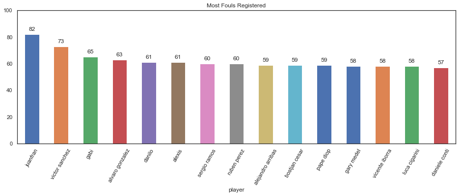

Gabi from Athletico Madrid is among the worst offenders - he features in top 3 in terms of both the number of fouls committed as well as the number of cards

## Which teams and players concede the maximum number of corners ?

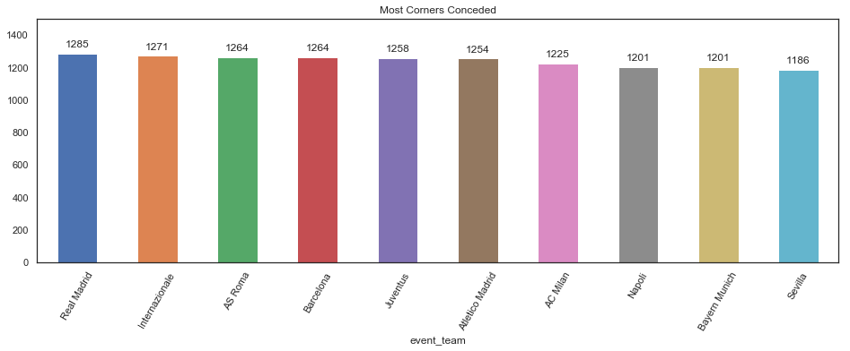

The top 10 list is dominated by La Liga (Real Madrid, Barcelona, Athletico Madrid, Sevilla) and Serie A (Internazionale, AS Roma, Juventus, AC Milan, Napoli)

So we can clearly conclude that teams in La Liga and Serie A concede more corners compared to other leagues

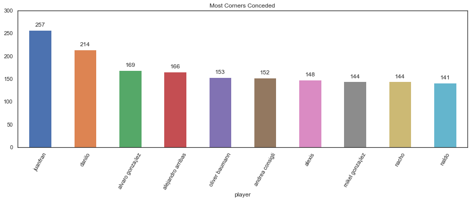

## Which players contribute the most through assists ?

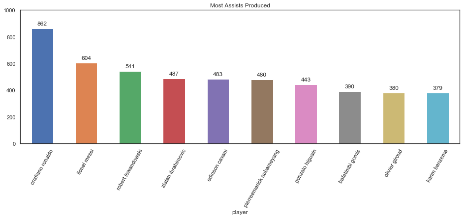

Higuain and Benzema also appear in the top 10 list indicating that they played a significant role behind Christiano Ronaldo's success as a goalscorer

## Messi vs Ronaldo - What does data indicate ?

Lets build a player comparator

|  | Goals | Misses | Attempts | Assists | Cards | Fouls | Offsides |
| --- | --- | --- | --- | --- | --- | --- | --- |
| lionel messi | 205 | 709 | 914 | 604 | 17 | 68 | 89 |
| cristiano ronaldo | 198 | 992 | 1190 | 862 | 29 | 100 | 206 |
| zlatan ibrahimovic | 153 | 621 | 774 | 487 | 29 | 248 | 225 |
| gonzalo higuain | 118 | 434 | 552 | 443 | 21 | 155 | 190 |
| luis suarez | 96 | 337 | 433 | 322 | 22 | 113 | 161 |
| karim benzema | 85 | 349 | 434 | 379 | 4 | 91 | 137 |
| gareth bale | 50 | 251 | 301 | 234 | 9 | 61 | 52 |
| harry kane | 65 | 288 | 353 | 278 | 9 | 85 | 78 |
| neymar | 58 | 260 | 318 | 248 | 23 | 106 | 69 |

## When are the most goals scored during a football match ?

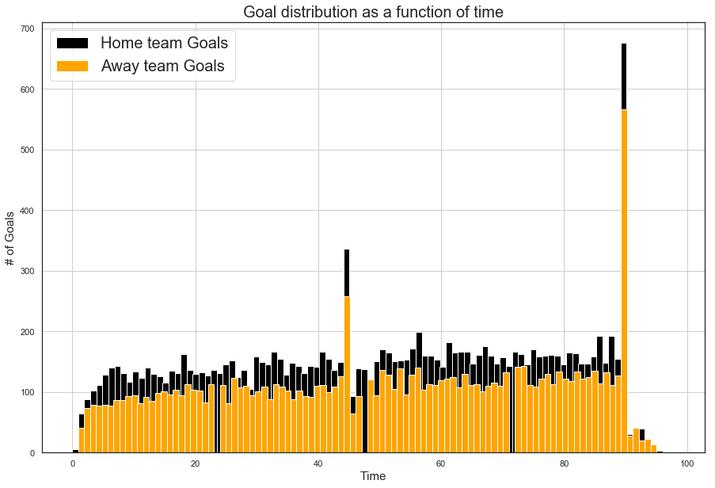

Interestingly there's a massive spike in number of goals just before half time and full time

## When do the most substitutions occur ?

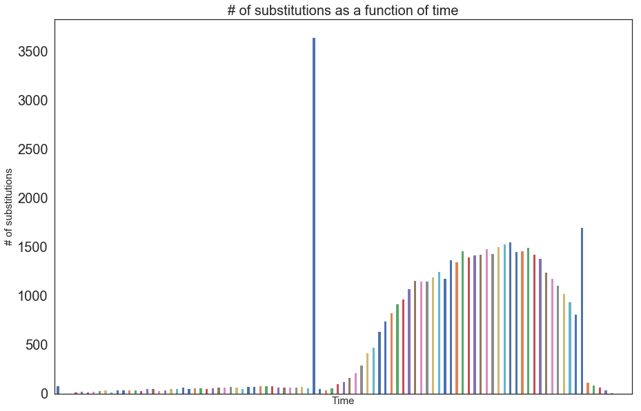

There's a massive spike in number of substitutions at around half time More substitutions happen during the second half of a match which makes logical sense

## When are the most number of red/yellow cards shown during a football match ?

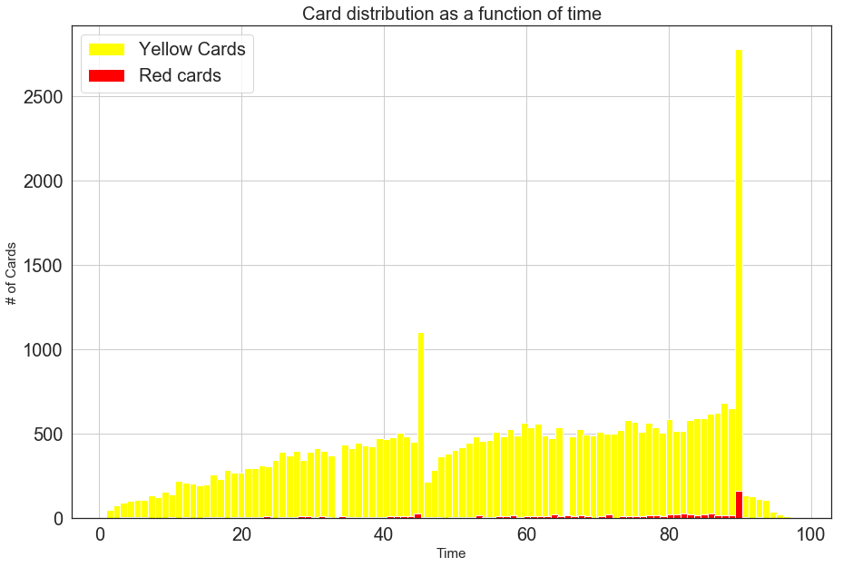

There's a spike in number of yellow cards just before half time and full time Most red cards are shown in last few minutes of a match (possibly when opponent is trailing by a goal and desperate to score and thus, the stakes are high) )

## Which players provide the most number of early breakthroughs ?

For our analysis we'll consider a goal scored in first 10 minutes of a match as an early breakthrough

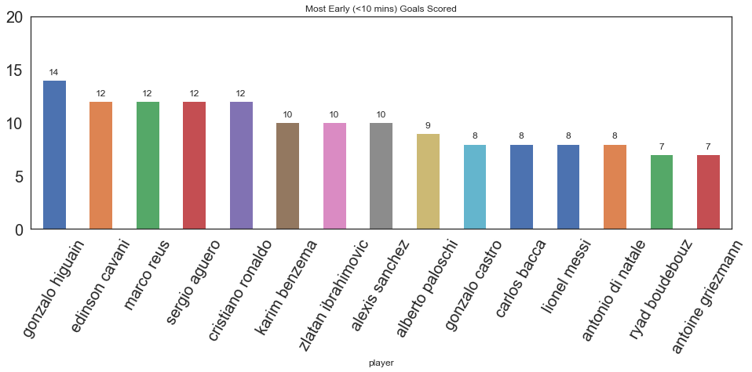

Let's look the corresponding team data as well

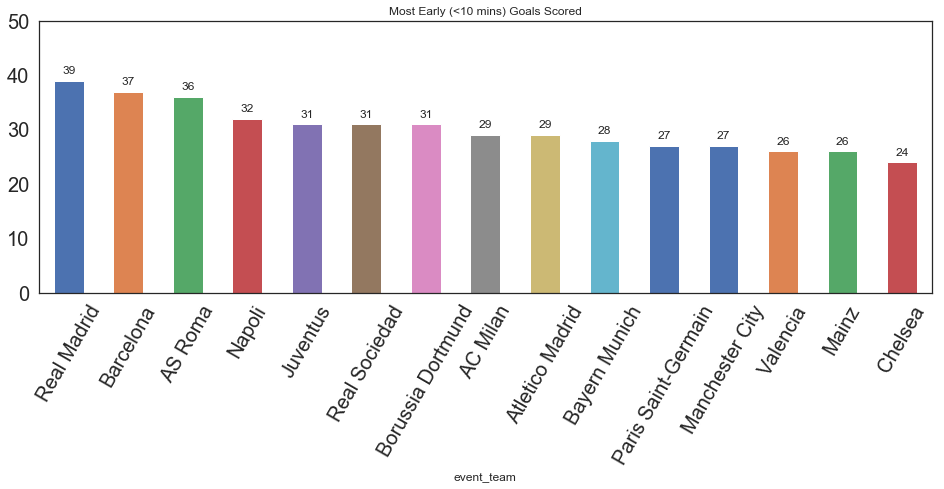

No surprises there. Real Madrid scores the maximum number of goals in first 10 minutes of a match

## Which players tend to score the most during last few minutes ?

For this, we will only consider goals scored after 85 minutes

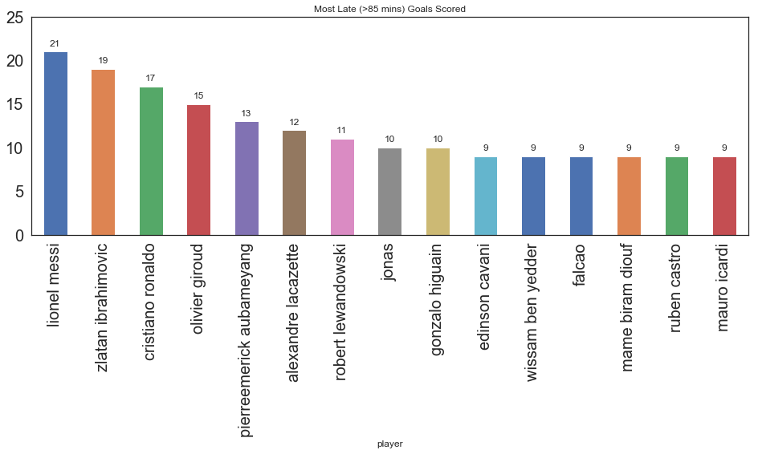

Again we have the same trio at top 3

Let's look at team level data as well

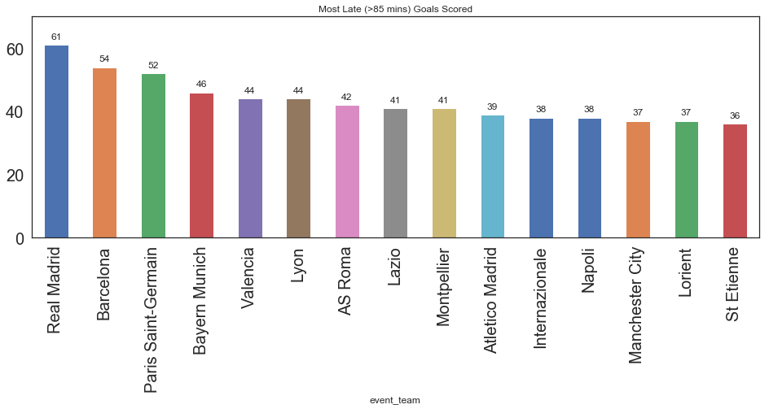

Just like early goals, Real Madrid leads in terms of number of late goals scored too

## Whats the best league to bet if you are a rookie ?

Let's do a league-wise analysis

A. **EPL**

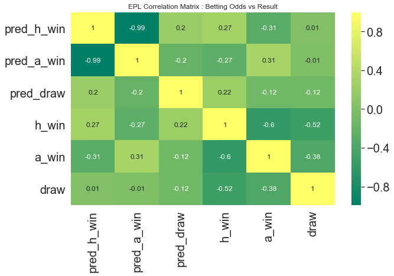

b) **La Liga**

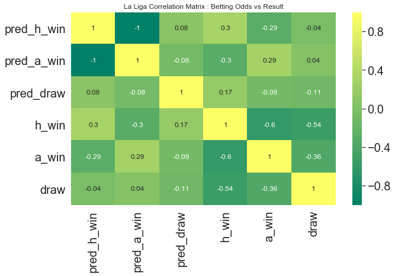

c) **Serie A**

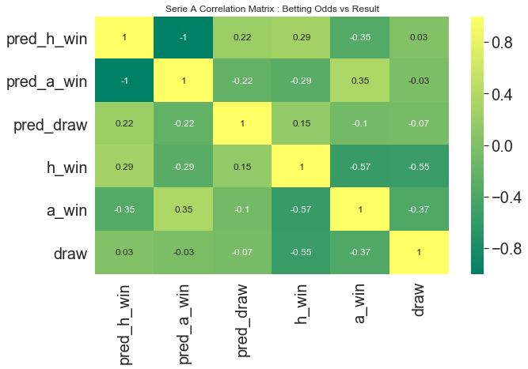

d) **Bundesliga**

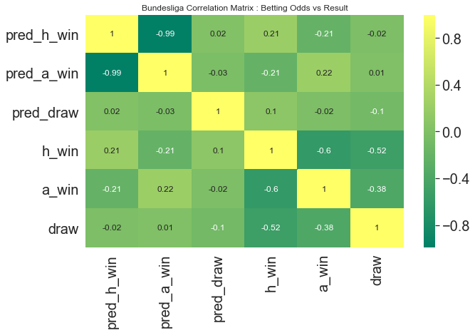

e) **Ligue One**

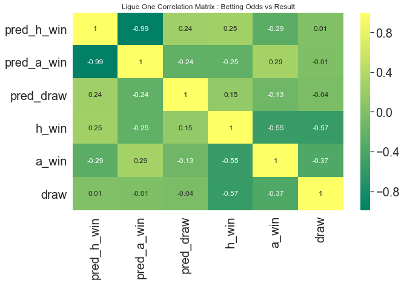

In general, the bookie odds are not a very good indicator of actual results

The odds for draw are the worst

Moral of the story : Dont rely on betting odds if you aim to get rich through betting !!